# More Trials, Better Trials, or More Tasks?

Simulation Insights for Accuracy Measures of Cognitive Individual Differences

Han Hao

October 2026 - Brown Bag Sesssion 1

# Background & Motivation

The measurement issue in individual differences research and the need of updated task designing in cognitive ToM.

## Individual differences Investigations

**It usually starts from an experimental task (group/condition-level differences) to a person measure**

- A cognitive task shows an experimental or quasi-experimental effect where people performed differently across different conditions.
- The conditions are designed and manipulated to engage different cognitive processes, or reflect different cognitive behaviors.
- We now want to use such task performance to rank people on a target cognitive ability.

## Some (related) decisions due to the behavioral research limitations

1. Which cognitive process(es) are we really measuring?
2. Which responses should count toward the score to represent individual differences reliably and validly?
3. How should we distribute trials (to different conditions) and the tasks (in different paradigms and/or in different stimuli)?

## A robust condition difference need not give stable person rankings

**Experimental question**

Do people’s *average* performance in one condition differ from the other *on average*?

**Individual-differences question**

Does a person’s score preserve a reproducible meaning reflecting their standings on certain “process”?

Hedge et al. tested RT and error difference measures in **seven classic cognitive tasks**. Test–retest ICCs were generally poor.

A dependable group effect and a dependable person measure require different evidence.

Hedge, Powell, & Sumner (2018), [The reliability paradox](https://doi.org/10.3758/s13428-017-0935-1).

## Repeating the same mixture can be very “reliable”

But does a reliable task really guarantee a solution to individual differences precision?

**Reliability/Repeatability**

Would the same people receive similar scores again?

**Validity/Process recovery**

Do those scores track the intended ability?

$$S_i = T_i + M_i + e_i$$

- $T$: intended process
- $M$: stable additional demand (?)
- $e$: response noise

**More trials can reduce response noise while preserving stable method/domain/paradigm influences.**

Trait–method distinction: Campbell & Fiske (1959), [multitrait–multimethod validation](https://doi.org/10.1037/h0046016).

## Quick example

A cognitive task intended to measure some core ability, e.g., memory retention, but also requires language comprehension (to read the materials).

- Both the exact paradigm and the required “extra” abilities will bring in stable impact to the performance.
- High reliability does not guarantee construct validity. If language ability is stable, repeated scores may consistently reflect both Core and language ability.

$$\text{Task Score}=\text{Memory}+\text{Language}+\text{Paradigm}+\text{Error}$$

## Potential measurement solutions

**Difference scoring based on the experimental design thinking**

- include a parallel task/condition with the same paradigm and stimuli, but don’t require “memory retention” (serving as the Control), subtracting the scores across the two versions to find a “pure” score of “memory retention”.
- **The E–C contrast has a clear experimental rationale.** Its person-level interpretation still depends on what both conditions require.

**Multiple-task setup based on psychometrics thinking**

- design memory tasks with paradigms and/or use stimuli that rely on different “extra” abilities, aggregate the scores to cancel the “unwanted components” out.
- **The multiple-task setup has a clear psychometrics rationale.** But people need to design and administer 2 or more task paradigms.

## Attention control: shared demands and extra conflict

**Some attention control measures applied the first solution.**

[figure not shown]

**Issues**

- Low reliability of the difference score measures (accuracy or RT).
- Common and specific abilities coexist in cognitive performance: A task (regardless the scoring approach) can reflect a common ability while retaining domain-specific requirements.

## Why subtraction is appealing and what it assumes

**Ideal additive case**

$$E_i = T_i + N_i,\qquad C_i = N_i,\qquad so \qquad E_i-C_i=T_i$$

The shared contribution $N$ cancels if it contributes to E & C in the **same and additive** way.

**Questions for actual accuracy data**

- Does C also engage the target process to some extent?
- Do processes really work additively, or can one become a bottleneck, a multiplier, or even a “log base” of the other?
- How much response uncertainty enters both estimated accuracies?

## Working memory: one label, different requirements

**Working memory capacity measures typically apply the 2nd solution (verbal, numerical, visuospatial, etc.).**

[figure not shown]

**Construct validity across task paradigms** may still have some issues

Various findings have indicated that **n-back and operation span correlated only weakly to moderately**, while each explained independent variation in fluid intelligence.

## Intelligence batteries covering different broad abilities by aggregating narrow ability performances

[figure not shown]

A precise measure of one domain may support a narrow inference. **A broad inference also needs justified coverage for core/target ability estimation**.

## Theory of mind: from experimental to individual differences

**what makes an answer correct DT task? And does it a reflection of individual differences in perspective taking?**

[figure not shown]

A correct choice in DT can depend on perspective use, selecting among objects, and understanding the instruction. **But how?**

## Empirical errors do not map neatly onto one process

For example, Legg et al. (2017) compared perspective-taking with a matched rule task.

| Task | Mean error rate on experimental trials |
| --- | --- |
| Level 1 perspective-taking | 16.7% |
| Level 2 perspective-taking | 10.0% |
| Rule following | 3.9% |

**Requiring perspective-taking affected errors; greater perspective complexity did not produce the predicted significant increase.**

Level 1 and Level 2 error rates were not significantly different, while both significantly different from the control (Rule-following).

## Simulation to investigate

- Generating subjects with **pure cognitive process scores** representing real human individual differences in cognition.
- Applying certain **algorithms to mimic potential cognitive mechanisms** of human responding behavioral stimuli.
- Scoring and analyzing these behavioral-level responses and **comparing them with the “true” cognitive process scores**.
- Comparing the resulting situations across scoring approaches, task “designs”, and even different algorithms representing certain cognitive mechanism hypotheses.

# Current Simulation Algorithms Overview

How the people, tasks, and responses were generated

## Simulating a process-mixture environment

**Basic schema:** three **Type** abilities share a core ability to different degrees, and each also has its own specific component. The type abilities are measured by different tasks in the same paradigm but with different stimulus format (verbal, numerical, spatial, etc.).

**Arbitrary decisions: separate task Type from stimulus Format**

| Local definitions/terms | Example interpretation | Shared variation across tasks |
| --- | --- | --- |
| Type | Paradigm or subconstruct | Core + Type-specific ability |
| Format | Verbal, numerical, spatial material | Format/stimuli-specific ability |
| Background | General demands of doing the task | Stable systematic additional ability |

**Simulating a crossed design of tasks, repeating each Type across all three Formats.**

## Two research questions for individual differences insights

Q1 · THE SCORING

**Same task battery, different scoring methods**

E+C, E−C, and E-only.

Which composite score is “better”? And whether estimated CFA factor scores help.

Q2 · THE ALLOCATION

**Same # of total trials, different allocation**

More Types, more tasks per Type, or more repetitive trials.

Use the scoring chosen in Q1 (for simplicity).

- **Better** here means which condition contributes to better reliability and core ability estimation.
- A systematic psychometric **good-versus-bad** item-task-quality comparison is reserved for future work.
- A cross-design comparison (scoring approach by allocation setup) is possible but **not included**.

## Simulating people before simulating tasks

We simulate each person’s **Core, Type, Format, and Background ability standings**.

Based on these “true” standings, we can apply certain responding mechanisms (higher abilities have higher likelihood of accurate responses) to simulate individual’s task performance.

$$\text{Known abilities}\ \longrightarrow\ \text{trial requirements}\ \longrightarrow\ 0/1\text{ responses}$$
We can ask whether an observed score or estimate recovers those known values (the true trait scores).

A single comparison across scoring approaches or allocations is within the same people. The next iteration draws a new “sample” of subjects.

Only accuracy indicators were considered in the current simulation design.

## What stays the same and what changes across iterations?

| Within one iteration of simulation | Across the iterations in a full cycle |
| --- | --- |
| Same 200 people and stable ability standings | New samples of 200 people each iteration |
| Same tasks in full edition (E and C trials) across 3 types and 3 formats | Same full bank of 9 tasks but randomly selected for different allocations |
| Shared responses are reused across comparisons | Fresh fluctuations and binary responses for each cohort |

**Think of one iteration as the new cohort doing all the same tasks and trials needed for different compared designs. The same task bank was used across iterations.**

**In each iteration, different scorings and allocations will select the completed trials and tasks from the full dataset.**

If two scores use the same response, it is literally the same saved response in one iteration.

## Build Core (target true) ability and Type abilities (paradigm/domain-biased core)

$$G_i,\ U_{i1},U_{i2},U_{i3}\ \overset{\mathrm{ind}}{\sim}\ N(0,1)$$

$$T_{ik}=\lambda_k G_i+\sqrt{1-\lambda_k^2}\,U_{ik}$$

| Type | Link to Core, $\lambda_k$ | Type-specific variance |
| --- | --- | --- |
| Type 1 | .90 | .1900 |
| Type 2 | .80 | .3600 |
| Type 3 | .45 | .7975 |

**Type** is loosely defined as subconstruct or (biased) core ability measured by a particular paradigm. **Correlations between 3 types can be calculated by the lambda products:** .72, .405, and .36.

## One generated person has several standardized process scores

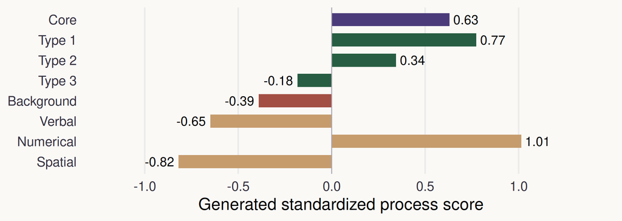

200 rows of process scores (ability standings) are generated and saved for an iteration. Process scores are used in combination with difficulty and discrimination parameters of trials in tasks, to generate binary accuracy responses.

## Nine tasks, with one full task in each cell

[figure not shown]

**One task per Type × Format cell.** No extra task versions (same a and b parameters to generate responses across cohorts).

Each full task has **90 E + 90 C potential trials**. The scoring comparison (section 1) uses the first **30 E + 30 C** in every task. The allocation comparison (section 2) uses **different numbers of trials** depending on the exact allocation.

Section 1 administration: 3 Types × 3 tasks × 60 trials = 540 responses per person.

## a and b parameters turn each process score into success

$$p_{igj} = \frac{e^{a_{gj}(\theta_{ig}-b_{gj})}}{1 + e^{a_{gj}(\theta_{ig}-b_{gj})}}$$

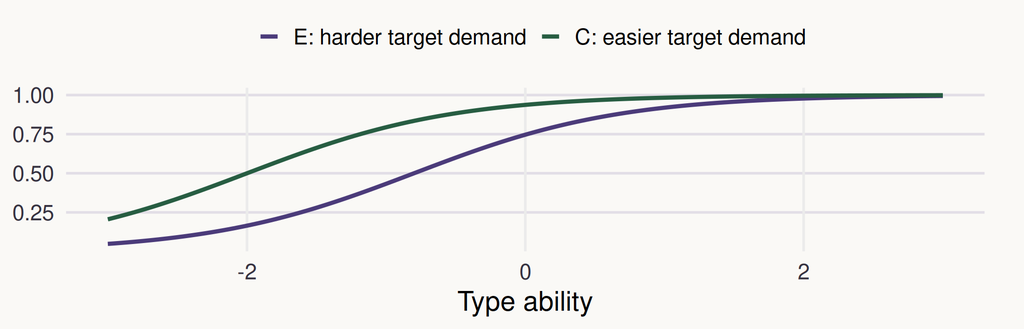

- $a$ (discrimination) controls steepness and $b$ (difficulty) locates the requirement.
- In this illustration: target $a=1.35$, $b_E=-.8$, $b_C=-2.0$.
- Actual items have varying parameters for each required ability and are matched by type and format, and by each pair of E & C trials.

## A weak required process can become the bottleneck

**Noncompensatory across abilities (A very strict bottleneck rule)**

$$p^*_{ij}=\min\{p_{\mathrm{Background}},p_{\mathrm{Format}},p_{\mathrm{Type}}\}$$

- The minimum means that the least successful required component controls the baseline probability. This is a simple and **very strict noncompensatory mechanism**.
- A strong process **cannot** rescue a weak required process. It is not necessarily how things work in reality.

**Momentary fluctuation and a binary response**: Added for “reliability” estimation

$$q_{ij}=\min\{1,\max(0,p^*_{ij}+.10z_{ij})\}, \quad z_{ij}\sim N(0,1)$$
$$Y_{ij}\sim\operatorname{Bernoulli}(q_{ij})$$

## Trace one actual person × item

| Required ability for T01, item 1, E | Success probability |
| --- | --- |
| Background | 0.885 |
| Verbal Format | 0.819 |
| Type 1 target | **0.818 — weakest** |

Fluctuation $z=$ -0.470.

$$q=.8177+.10(-.4698)=.7707$$

**Observed answer:** correct (1). A probability is not a guaranteed outcome.

## What counts as successful measurement?

| Question | Statistic in this simulation |
| --- | --- |
| Recover the core ability? | $r(S_i,G_i)$ |
| Recover each measured Type? | Mean of $r(S_{ik},T_{ik})$ across measured Types |
| Reproduce person scores? | $r(S_i^{(1)},S_i^{(2)})$ * |
| Retain other process influences? | Background, random flunctuation that are not designed, etc. |

**Compute each correlation within a 200-person cohort, then summarize the point estimates across cohorts.**

*Reliability (repeatbility) in the simulation was calculated by regenerating a full set of responses for unchanged people and items. It is not an empirical test–retest reliability estimate, I actually “asked” the same people to do the same tasks twice.

# What do the current results tell us?

**Section 1a:** Three scoring approaches from the same responses.

**Section 1b:** Core factor-score recovery from fitted CFA models.

**Section 2:** Task allocation under a fixed 270 E-trial budget.

## Section 1a: Three scoring approaches from the same battery

| Scoring approach | Task score | Responses included | First person’s T01 score |
| --- | --- | --- | --- |
| E+C (all composite) | $(\bar E+\bar C)/2$ | 540 | .783 |
| E−C (different score) | $\bar E-\bar C$ | 540 | .033 |
| E-only (exp-trial composite) | $\bar E$ | 270 | .800 |

**For Person 1 on Task 1:** 24/30 E answers and 23/30 C answers were correct.

**Task scores were averaged equally at the Type and battery levels for corresponding battery/type scores.**

All three scoring methods use one administration of 540 trials. E-only retains the 270 E responses. The signed E−C score can be negative but the ranking should stay in the same direction.

## Section 1a: E-only recovers core and types best

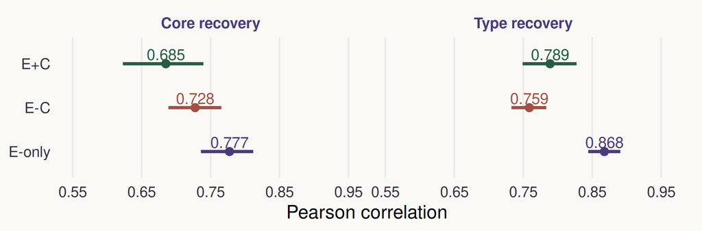

**Error bars** were actually 10th–90th percentiles (across all point estimates).

## Section 1a: High reliability does not equal to best core recovery

**The E + C scoring had the highest “Test-retest” reliability in general**

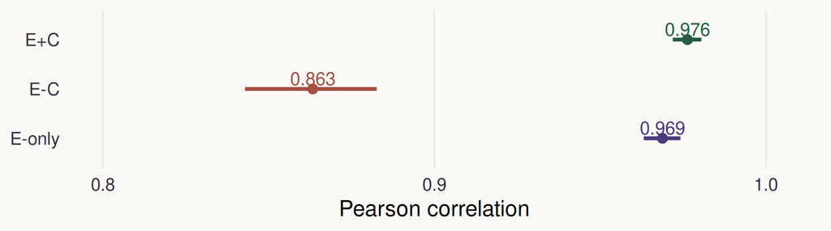

**E+C:** best reliability, worst core recovery

**E-only:** best core and type recovery

**E-C:** moderate core recovery, worst type recovery and reliability

Again, **Error bars** were 10th–90th percentiles (across all point estimates).

## Section 1a: Why subtraction is not a pure target score here

**I did not simulate the cognitive engagement in an additive fashion:** Both E and C trials still engage the target in some way; C makes that requirement easier. It changes the meaning of a simple subtraction.

Specifically, I did a **non-compensatory, bottleneck** design.

Illustration: for two people with the same fix target success at **E = .70, C = .90** but different background ability.

| Background success | E probability | C probability | E−C |
| --- | --- | --- | --- |
| .50 — limits both conditions | .50 | .50 | .00 |
| .95 — target becomes limiting | .70 | .90 | −.20 |

The difference changes with Background even when the target is unchanged.

## Section 1b: Estimate Core from a higher-order CFA

[figure not shown]

**Nine task composites (3 scoring approaches) → three first-order Type factors → high-order Core.**

Continuous linear CFA, MLR estimation.

## Section 1b: All models converged

**But Some estimated a negative latent variance (potential Heywood cases) because of the high-order CFA structure**.

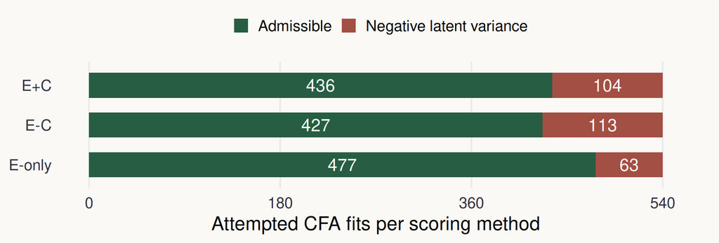

## Section 1b: Core factor scores help core recovery across all 3 scoring approaches

**Cohorts (samples) with any Heywood model were not included in ths summary.**

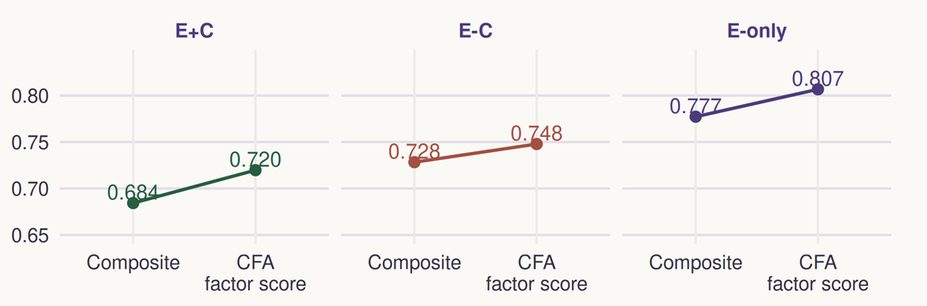

**E-only still gives the highest core recovery correlation:** composite score .777 → CFA factor score .807.

## Section 1b: An actual fitted E-only CFA

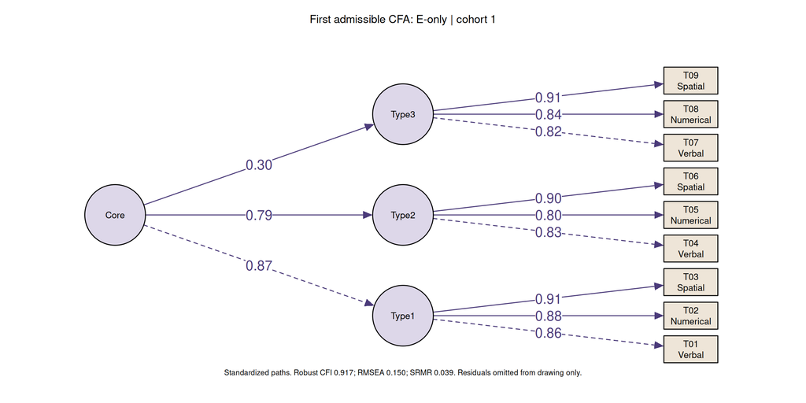

**Standardized estimates describe this selected model only**, not population-level summary of loadings from multiple models.

## Section 1b: Patterns differ in model fits

| Score | Mean robust CFI | Mean robust RMSEA | # of non-Heywood models |
| --- | --- | --- | --- |
| E+C | 0.767 | 0.262 | 436 |
| E−C | 0.982 | 0.034 | 427 |
| E-only | 0.939 | 0.130 | 477 |

I don’t know why it is the case, yet :(

## Section 2: If we have a fixed budget, how should we allocate the tasks?

**How do we collect the data on 270 trials to estimate the target ability precisely?**

| Battery | Types | Tasks per Type | E trials per task | Total |
| --- | --- | --- | --- | --- |
| Broad coverage, short tasks | 3 | 3 | 30 | 270 |
| Moderate coverage, long tasks | 3 | 1 | 90 | 270 |
| One type, three tasks | 1 | 3 | 90 | 270 |
| One really long task | 1 | 1 × 3 times | 90 | 270 |

**All use E-only based on the results from Section 1a; no C trials are administered in Section 2.**

## Section 2: Broad coverage recovers core ability better on average

**The moderate coverage with long tasks is also not bad.**

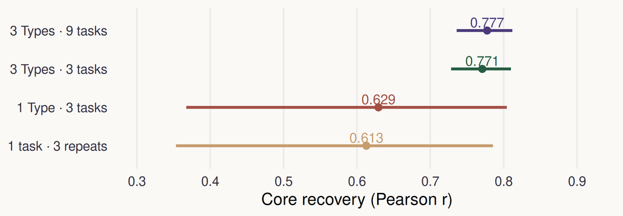

The unstable performance of the later two allocations were due to the lower correlation of Type 3 to the core ability. If your paradigm is more domain-specific, there will be issues with narrow coverage.

Again, **Error bars** were 10th–90th percentiles (across all the point estimates).

## Section 2: A one-Type battery can be stable and recover that Type

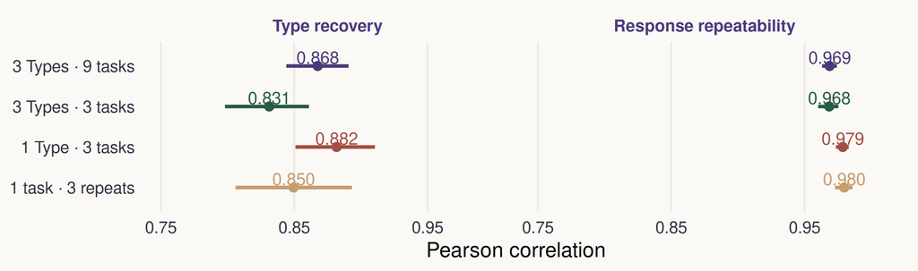

More trials refines within Type; they do not erase its specificity.

# Discussion, Limitation, & Future Direction

For this ongoing simulation project…

## “Old folk tales” generally reassured

1. **Reliability and validity, and operational definitions with task paradigms.** A stable score can consistently retain other abilities.
2. **The utility of difference score is questionable, depending on the applicability of additive effects.** Its value depends on shared processes, how they combine, and response precision.
3. **Be cautious of what you are measuring: Match coverage to the intended construct.** More trials may not be better than more tasks.

Define the intended inference first, then operationalized definition of constructs, then justify the tasks, conditions, scoring, and/or latent variable model.

## What remains uncertain and what to test next

**Current assumptions**

- Minimum-probability rule: a bucket-effect type of non-compensatory mechanism
- Independent trial fluctuations (from person, from background, etc.)
- Static process scores, 2PL response generation, and matched item parameters.

**Future extensions**

- C with no potential target process demand at all.
- Other potential compensatory mechanism of process engagement.
- RT vs. Accuracy, DDT-based data generation (?)

## Questions of our (my?) time

**What can we improve now in the measurement of cognitive individual differences?**

- Moderate(?)-hanging fruit: task design, scoring, better psychometric modeling, transparent validity inspections.
- Harder question: are some limits of cognitive mechanisms really approachable via conventional, simple models on behavioral measures, or are they not “modelable” given the nature of complex behavior as **complex** system?

## Declarations

- This is an ongoing project that has been **heavily assisted by AI**. All results might be temporary.
- The central research idea, research questions, and general simulation and analysis workflow were generated independently by me.
- AI was used to help develop the exact simulation execution R scripts and support parts of the revision and implementation process.
- The visualizations in the current slides were generated and formatted by AI based on saved simulation results.
- All interpretation and final wording in the current slides were reviewed and edited by me.